# Model 0: A LASSO Rehearsal on Predisposing Variables

Testing our reading of Section 5.4 before committing to it

Author

Analysis Team

Published

July 31, 2026

# Mission

Section 5.4 of the project proposal specifies variable selection by LASSO. Before applying that procedure to the full predictor set across four model specifications, nineteen condition-specific subgroups, and two sex strata, this report rehearses the machinery once, on a single Andersen domain, against a single outcome.

Model 0 is deliberately **not** a findings report. It is a feasibility check whose deliverable is a list of decisions that Section 5.4 leaves open, together with evidence about how each decision would bite. Nothing here should be cited as a substantive result.

**Research questions:**

1. What does the L1 penalty actually do to coefficients as it tightens?
2. How do `lambda.min` and `lambda.1se` differ in what they retain?
3. When Section 5.4 counts “16 variables”, is it counting variables or columns?
4. Does the Poisson-to-negative-binomial handoff work mechanically?
5. Do the survey weights disturb cross-validation, and if so, how much?
6. What does a retained set mean when the predictor universe is deliberately narrow?

# Definition of Terms

**LASSO.** A penalized regression that maximizes the log-likelihood minus $\lambda \sum_j |\beta_j|$. Because the absolute-value penalty has a corner at zero, it drives some coefficients *exactly* to zero rather than merely shrinking them. It therefore performs shrinkage and subset selection in one convex optimization, replacing the unstable, path-dependent search of stepwise methods with a continuous one governed by a single tuning parameter.

**`lambda.min`.** The penalty that minimizes cross-validated deviance. Permissive: retains more predictors.

**`lambda.1se`.** The largest penalty whose cross-validated deviance still sits within one standard error of the minimum. The “one-standard-error rule” buys parsimony at a cost in fit that cross-validation cannot distinguish from noise.

**Design column.** After dummy coding, a factor with $k$ levels becomes $k-1$ columns. LASSO operates on columns, not on variables. A four-level factor can have two columns retained and two eliminated.

**Perceived health variables.** Following the decision recorded for this project, these are exactly three: `health_perceived`, `mental_health_perceived`, and `health_vs_prior_year`. The functional-limitation items (`adl_*`) and `injured_past_12m` remain in every specification. None of the five appear in Model 0, which is restricted to the predisposing domain.

**Outcome.** `days_absent_chronic`, the sensitivity outcome of Section 4.1: workdays lost to chronic conditions in the three months before the survey.

# Environment

**Packages used in the current report**

```r
library(magrittr)
library(ggplot2)
library(dplyr)
library(tidyr)
library(forcats)
library(purrr)
library(tibble)
library(scales)
library(fs)
library(kableExtra)
requireNamespace("arrow", quietly = TRUE)
requireNamespace("glmnet", quietly = TRUE)
requireNamespace("MASS", quietly = TRUE)
requireNamespace("Matrix", quietly = TRUE)
requireNamespace("knitr", quietly = TRUE)
```

**Project functions and Alberta visual identity colours**

```r
base::source("./scripts/common-functions.R")
base::source("./scripts/graphing/graph-presets.R")
```

**Paths, seed, outcome, and the predisposing variable set**

```r
local_root <- "./analysis/model-0/"
local_data <- paste0(local_root, "data-local/")
prints_folder <- paste0(local_root, "prints/")
path_parquet <- "./data-private/derived/cchs-2-tables/cchs_analytic.parquet"

outcome_var <- "days_absent_chronic"
weight_col <- "wts_m_pooled"
cycle_var <- "cchs_cycle_f"
lasso_seed <- 42
lasso_folds <- 5

if (!fs::dir_exists(local_data)) { fs::dir_create(local_data) }
if (!fs::dir_exists(prints_folder)) { fs::dir_create(prints_folder) }

# Predisposing domain per stats_instructions_v3.md Section 2.2.
# `dhhgage` is deliberately excluded: it is the same construct as `age_group_3`
# at finer resolution, and the proposal specifies the 3-category recode.
#
# `dhhgl12` is also excluded, ratified 2026-08-01. It is the logical OR of
# `dhhgle5` and `dhhg611` in all 63,843 rows, so all three together span the same
# column space as `dhhgle5 * dhhg611`. This report exists to demonstrate how the
# penalty behaves, and a deterministically redundant column would demonstrate the
# wrong thing: the penalty would split one shared coefficient arbitrarily between
# the three. It is retained for descriptive and bivariate reporting in model-00.
# See `bivariate_only_vars` in scripts/modeling/candidate-registry.R.
#
# `home_ownership` was admitted 2026-08-01 after QC established that `DHH_OWN` is
# present in both cycles with 99.74% coverage; it satisfies the Section 2.2
# "homeownership" requirement that was previously believed to have no PUMF
# equivalent.
predisposing_specs <- tibble::tribble(
  ~variable, ~variable_label,
  "age_group_3", "Age group",
  "sex", "Sex",
  "marital_status", "Marital status",
  "household_size", "Household size",
  "dhhgle5", "Child aged 0-5 in household",
  "dhhg611", "Child aged 6-11 in household",
  "education", "Education",
  "immigration_status", "Immigration status",
  "visible_minority", "Visible minority",
  "home_ownership", "Home ownership",
  "living_arrangements", "Living arrangements"
)

predisposing_vars <- predisposing_specs$variable

# `cchs_cycle_f` is forced into every model (penalty.factor = 0) because the
# pooled design requires a cycle indicator regardless of selection outcome.
forced_vars <- cycle_var

lambda_colours <- c(
  "lambda.1se" = abcol[["magenta"]],
  "lambda.min" = abcol[["blue"]]
)

# Used by the stage-two forest plot to separate terms whose Wald interval clears
# the null from those whose does not. Not a significance test: see the caveat in
# the "Stage Two" section about what these intervals ignore.
interval_colours <- c(
  "Interval excludes 1" = abcol[["blue"]],
  "Interval includes 1" = "grey65"
)
```

**Helpers for table rendering, design-matrix mapping, and coefficient extraction**

```r
# Render a data frame as styled HTML for Quarto, or plainly for console use.
print_table <- function(data, caption, align = NULL) {
  html <- data %>%
    knitr::kable(
      format = "html",
      caption = caption,
      escape = FALSE,
      align = align,
      row.names = FALSE
    ) %>%
    kableExtra::kable_styling(
      bootstrap_options = c("striped", "hover", "condensed"),
      full_width = FALSE
    ) %>%
    kableExtra::scroll_box(width = "100%") %>%
    as.character()
  cat(html)
  invisible(data)
}

# Convert 0/1 numeric indicators into labelled factors so that model.matrix
# produces one interpretable dummy column per indicator.
to_yes_no <- function(x) {
  factor(ifelse(x == 1, "Yes", "No"), levels = c("No", "Yes"))
}

# Map every design-matrix column back to the source variable that generated it.
# This is what makes the "how many variables did LASSO keep?" question answerable.
map_columns_to_variables <- function(model_frame, model_formula) {
  mm <- stats::model.matrix(model_formula, data = model_frame)
  assign_index <- attr(mm, "assign")
  term_labels <- attr(stats::terms(model_formula, data = model_frame), "term.labels")
  source_variable <- c("(Intercept)", term_labels)[assign_index + 1]

  keep <- colnames(mm) != "(Intercept)"
  list(
    x = mm[, keep, drop = FALSE],
    map = tibble::tibble(
      column = colnames(mm)[keep],
      variable = source_variable[keep]
    )
  )
}

# Strip the variable-name prefix from a design-matrix column to recover the
# level label. Vectorized, because `sub()` uses only the first pattern element.
strip_variable_prefix <- function(column, variable) {
  purrr::map2_chr(column, variable, ~ sub(paste0("^", .y), "", .x))
}

# Extract a tidy coefficient vector from a cv.glmnet fit at a named lambda.
extract_coefficients <- function(cv_fit, lambda_label) {
  coefficient_matrix <- stats::coef(cv_fit, s = lambda_label)
  tibble::tibble(
    column = rownames(coefficient_matrix),
    estimate = as.numeric(coefficient_matrix)
  ) %>%
    filter(column != "(Intercept)")
}
```

# Data

**Load the Ellis respondent-level analytical parquet**

```r
ds0 <- arrow::read_parquet(path_parquet)
```

**Build the model frame and design matrix**

```r
# Build the model frame. Three transformations matter for LASSO:
#   1. Ordered factors become unordered, so model.matrix emits readable dummy
#      columns instead of polynomial contrasts (.L, .Q, .C).
#   2. Binary numeric indicators become No/Yes factors.
#   3. Complete-case restriction, because glmnet cannot accept a design matrix
#      with missing cells.
ds1 <- ds0 %>%
  select(
    all_of(c(outcome_var, weight_col, cycle_var, predisposing_vars))
  ) %>%
  mutate(across(where(is.ordered), ~ factor(., ordered = FALSE))) %>%
  mutate(across(any_of(c("dhhgle5", "dhhg611", "dhhgl12")), to_yes_no)) %>%
  mutate(across(where(is.character), factor))

n_before_complete_case <- nrow(ds1)

ds1 <- ds1 %>%
  tidyr::drop_na() %>%
  mutate(
    .respondent_id = dplyr::row_number(),
    weight_scaled = .data[[weight_col]] / mean(.data[[weight_col]])
  )

n_after_complete_case <- nrow(ds1)

model_formula <- stats::reformulate(c(forced_vars, predisposing_vars))
design <- map_columns_to_variables(ds1, model_formula)
x_matrix <- design$x
y_outcome <- ds1[[outcome_var]]
weight_vector <- ds1$weight_scaled
penalty_vector <- as.numeric(!design$map$variable %in% forced_vars)

variable_labels <- c(
  stats::setNames(predisposing_specs$variable_label, predisposing_specs$variable),
  stats::setNames("CCHS cycle", cycle_var)
)
```

Two preparation choices deserve to be visible rather than buried.

```
Rows before complete-case restriction:  63843
```

```
Rows after complete-case restriction:   62017
```

```
Rows dropped:  1826  (2.86%)
```

```
Design matrix dimensions:  62017  x  27
```

## Data Context

For complete data documentation, see the Univariate Distributions Data Primer, especially Section 3, Predisposing Variables. The outcome is profiled in EDA-71, and its relationship to these predictors in EDA-72.

**Which table and columns this analysis uses**

```r
# Single source table: the Ellis analytic parquet, one row per respondent.
# Variables drawn from it fall into four roles.
tibble::tibble(
  role = c("Outcome", "Survey weight", "Forced covariate", "Candidate predictors"),
  columns = c(
    outcome_var,
    weight_col,
    cycle_var,
    paste(predisposing_vars, collapse = ", ")
  ),
  rationale = c(
    "Sensitivity outcome of Section 4.1: workdays lost to chronic conditions",
    "Pooled master weight; rescaled to mean 1 for numerical stability",
    "Pooled design requires a cycle indicator in every specification",
    "Predisposing domain of the Andersen model, Section 2.2"
  )
) %>%
  print_table(
    caption = "Source table `cchs_analytic.parquet` and the role of each column",
    align = c("l", "l", "l")
  )
```

Source table `cchs_analytic.parquet` and the role of each column

| role | columns | rationale |
| --- | --- | --- |
| Outcome | days_absent_chronic | Sensitivity outcome of Section 4.1: workdays lost to chronic conditions |
| Survey weight | wts_m_pooled | Pooled master weight; rescaled to mean 1 for numerical stability |
| Forced covariate | cchs_cycle_f | Pooled design requires a cycle indicator in every specification |
| Candidate predictors | age_group_3, sex, marital_status, household_size, dhhgle5, dhhg611, education, immigration_status, visible_minority, home_ownership, living_arrangements | Predisposing domain of the Andersen model, Section 2.2 |

**One illustrative respondent reporting chronic absence days**

```r
# One respondent who reported chronic absence days, shown across every column
# that enters the model.
set.seed(lasso_seed)
example_row <- ds1 %>%
  filter(.data[[outcome_var]] > 0) %>%
  slice_sample(n = 1)

example_row %>%
  select(-.respondent_id) %>%
  tidyr::pivot_longer(
    cols = everything(),
    names_to = "column",
    values_transform = as.character,
    values_to = "value"
  ) %>%
  print_table(
    caption = "Every modelled column for one respondent reporting chronic absence days",
    align = c("l", "l")
  )
```

Every modelled column for one respondent reporting chronic absence days

| column | value |
| --- | --- |
| days_absent_chronic | 3 |
| wts_m_pooled | 51.4 |
| cchs_cycle_f | 2013-2014 |
| age_group_3 | 25-54 |
| sex | Female |
| marital_status | Widowed / Separated / Divorced |
| household_size | 1 person |
| dhhgle5 | No |
| dhhg611 | No |
| education | Secondary graduate |
| immigration_status | Non-immigrant (Canadian-born) |
| visible_minority | White |
| home_ownership | Owner |
| living_arrangements | Unattached, living alone |
| weight_scaled | 0.184131927543299 |

**Levels, dummy columns, and reference level for each predictor**

```r
# Level counts for each candidate predictor, plus the dummy columns each yields.
design$map %>%
  count(variable, name = "design_columns") %>%
  left_join(
    ds1 %>%
      select(all_of(c(forced_vars, predisposing_vars))) %>%
      summarise(across(everything(), ~ length(levels(factor(.))))) %>%
      tidyr::pivot_longer(everything(), names_to = "variable", values_to = "levels"),
    by = "variable"
  ) %>%
  mutate(
    variable_label = variable_labels[variable],
    reference_level = purrr::map_chr(variable, ~ levels(factor(ds1[[.x]]))[1])
  ) %>%
  select(variable, variable_label, levels, design_columns, reference_level) %>%
  arrange(variable) %>%
  print_table(
    caption = "Candidate predictors: observed levels, dummy columns, and reference level",
    align = c("l", "l", "r", "r", "l")
  )
```

Candidate predictors: observed levels, dummy columns, and reference level

| variable | variable_label | levels | design_columns | reference_level |
| --- | --- | --- | --- | --- |
| age_group_3 | Age group | 3 | 2 | 15-24 |
| cchs_cycle_f | CCHS cycle | 2 | 1 | 2010-2011 |
| dhhg611 | Child aged 6-11 in household | 2 | 1 | No |
| dhhgle5 | Child aged 0-5 in household | 2 | 1 | No |
| education | Education | 4 | 3 | Less than secondary |
| home_ownership | Home ownership | 2 | 1 | Owner |
| household_size | Household size | 5 | 4 | 1 person |
| immigration_status | Immigration status | 3 | 2 | Non-immigrant (Canadian-born) |
| living_arrangements | Living arrangements | 8 | 7 | Unattached, living alone |
| marital_status | Marital status | 4 | 3 | Married |
| sex | Sex | 2 | 1 | Male |
| visible_minority | Visible minority | 2 | 1 | White |

**Respondent grain proof**

```r
# Grain proof: one row per respondent, no duplicate identifiers.
cat("Unit of analysis: one row per CCHS respondent\n")
```

```
Unit of analysis: one row per CCHS respondent
```

**Respondent grain proof**

```r
cat("Rows: ", nrow(ds1), "\n")
```

```
Rows:  62017
```

**Respondent grain proof**

```r
cat("Distinct respondent ids: ", dplyr::n_distinct(ds1$.respondent_id), "\n")
```

```
Distinct respondent ids:  62017
```

**Respondent grain proof**

```r
cat("Duplicate rows: ", sum(duplicated(ds1$.respondent_id)), "\n")
```

```
Duplicate rows:  0
```

# Analysis

## The Problem Being Solved

Two facts frame the exercise. Output out2 shows the first: the outcome is severely zero-inflated and its variance exceeds its mean by more than an order of magnitude. A Poisson model, which assumes those two quantities are equal, is therefore misspecified from the start. This is precisely why Section 5.4 uses Poisson only as a *selection* device and re-estimates with negative binomial.

**Weighted outcome moments and the dispersion ratio**

```r
outcome_values <- ds1[[outcome_var]]
outcome_mean <- stats::weighted.mean(outcome_values, weight_vector)
outcome_var_weighted <- sum(weight_vector * (outcome_values - outcome_mean)^2) /
  (sum(weight_vector) - 1)

cat("Outcome: ", outcome_var, "\n")
```

```
Outcome:  days_absent_chronic
```

**Weighted outcome moments and the dispersion ratio**

```r
cat("Weighted mean:      ", sprintf("%.4f", outcome_mean), "\n")
```

```
Weighted mean:       0.3670
```

**Weighted outcome moments and the dispersion ratio**

```r
cat("Weighted variance:  ", sprintf("%.4f", outcome_var_weighted), "\n")
```

```
Weighted variance:   6.4504
```

**Weighted outcome moments and the dispersion ratio**

```r
cat("Variance / mean:    ", sprintf("%.2f", outcome_var_weighted / outcome_mean),
    "  (Poisson assumes 1.0)\n")
```

```
Variance / mean:     17.58   (Poisson assumes 1.0)
```

**Weighted outcome moments and the dispersion ratio**

```r
cat("Proportion of zeros:", sprintf("%.2f%%", 100 * mean(outcome_values == 0)), "\n")
```

```
Proportion of zeros: 94.31%
```

**Weighted outcome moments and the dispersion ratio**

```r
cat("Maximum observed:   ", max(outcome_values), "\n")
```

```
Maximum observed:    31
```

Table t1 shows the second fact, and it answers Research Question 3 directly. Eleven predisposing variables plus the cycle indicator do not produce twelve columns. They produce twenty-seven.

**Variable-to-column expansion in the design matrix**

```r
# The variable-to-column expansion. This table is the empirical answer to the
# ambiguity in Section 5.4: "16 variables" may mean 16 factors or 16 columns.
design$map %>%
  mutate(variable_label = variable_labels[variable]) %>%
  group_by(variable, variable_label) %>%
  summarise(
    design_columns = n(),
    columns = paste(strip_variable_prefix(column, variable), collapse = "; "),
    .groups = "drop"
  ) %>%
  arrange(desc(design_columns), variable) %>%
  select(Variable = variable_label, `Design columns` = design_columns,
         `Non-reference levels` = columns) %>%
  bind_rows(
    tibble::tibble(
      Variable = "TOTAL",
      `Design columns` = ncol(x_matrix),
      `Non-reference levels` = ""
    )
  ) %>%
  print_table(
    caption = paste0(
      "Table t1: Twelve candidate variables expand into ", ncol(x_matrix),
      " design-matrix columns"
    ),
    align = c("l", "r", "l")
  )
```

Table t1: Twelve candidate variables expand into 27 design-matrix columns

| Variable | Design columns | Non-reference levels |
| --- | --- | --- |
| Living arrangements | 7 | Unattached, living with others; Couple, no children; Couple with children; Single parent with child; Child in parent / sibling household; Child in two-parent / sibling household; Other arrangement |
| Household size | 4 | 2 persons; 3 persons; 4 persons; 5 or more persons |
| Education | 3 | Secondary graduate; Some post-secondary; Post-secondary graduate |
| Marital status | 3 | Common-law; Widowed / Separated / Divorced; Single / Never married |
| Age group | 2 | 25-54; 55-75 |
| Immigration status | 2 | Long-term immigrant (10+ yrs in Canada); Recent immigrant (0-9 yrs in Canada) |
| CCHS cycle | 1 | 2013-2014 |
| Child aged 6-11 in household | 1 | Yes |
| Child aged 0-5 in household | 1 | Yes |
| Home ownership | 1 | Renter |
| Sex | 1 | Female |
| Visible minority | 1 | Visible minority |
| TOTAL | 27 |  |

This has a consequence that the proposal’s phrasing does not settle. Section 5.4 sets targets of 16, 9, 32, and 33 “variables” for the four models. Because LASSO selects columns, a result can be reported two ways, and the two counts will not agree. Model 0 reports both throughout so the discrepancy stays visible.

## Graph Family g1: Fitting the Penalized Path

Graph g1 is the picture worth carrying away. Each line is one design column. Read right to left: at the far right the penalty is so heavy that every penalized coefficient is pinned at zero. As $\lambda$ relaxes, coefficients peel away from the axis one at a time. Selection is not a separate step applied after fitting; it *is* the fitting, viewed at a particular penalty.

The cycle indicator is the one line that never touches zero. It carries `penalty.factor = 0`, which exempts it from the penalty entirely, because the pooled design requires a cycle term whether or not it earns its place.

**Fit the full LASSO path and the cross-validated fit**

```r
set.seed(lasso_seed)
lasso_path <- glmnet::glmnet(
  x = x_matrix,
  y = y_outcome,
  family = "poisson",
  alpha = 1,
  weights = weight_vector,
  penalty.factor = penalty_vector
)

set.seed(lasso_seed)
cv_fit <- glmnet::cv.glmnet(
  x = x_matrix,
  y = y_outcome,
  family = "poisson",
  alpha = 1,
  nfolds = lasso_folds,
  weights = weight_vector,
  penalty.factor = penalty_vector
)

lambda_1se <- cv_fit$lambda.1se
lambda_min <- cv_fit$lambda.min

path_long <- as.matrix(lasso_path$beta) %>%
  as.data.frame() %>%
  tibble::rownames_to_column("column") %>%
  tidyr::pivot_longer(-column, names_to = "step", values_to = "estimate") %>%
  mutate(lambda = lasso_path$lambda[as.integer(sub("^s", "", step)) + 1]) %>%
  left_join(design$map, by = "column") %>%
  mutate(variable_label = variable_labels[variable])

saveRDS(cv_fit, paste0(local_data, "cv_fit.rds"))
```

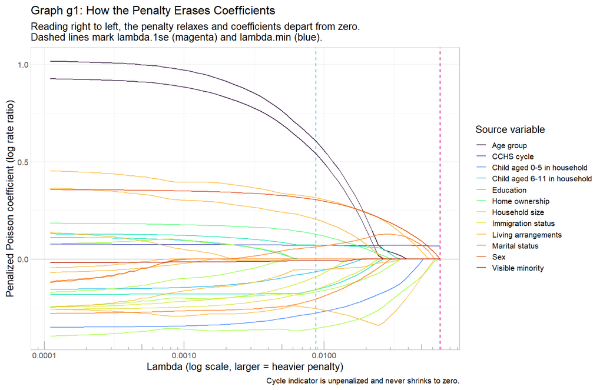

Graph g1: Each line traces one design-matrix column across the penalty grid. Coefficients leave zero one at a time as the penalty relaxes. The unpenalized cycle indicator is the only line that never touches zero.

### Reading the Vertical Axis

The quantity on the vertical axis is a coefficient from a Poisson GLM with a log link,

$$\log \mathbb{E}[Y_i \mid X_i] = \beta_0 + \sum_j \beta_j x_{ij},$$

so it lives on the log-count scale, not the day scale. The word *penalized* means $\hat\beta$ is not the maximum-likelihood estimate; it solves

$$\hat\beta(\lambda) = \arg\max_\beta \; \ell_{\text{Poisson}}(\beta) - \lambda \sum_j c_j |\beta_j|,$$

with $c_j = 1$ for the predisposing dummies and $c_j = 0$ for the cycle indicator. Two consequences follow. Every plotted value is deliberately biased toward zero, by an amount that grows with $\lambda$. And no standard error, confidence interval, or p-value attaches to it — LASSO coefficients admit no valid Wald inference. This is exactly why stage two re-estimates the selected set with negative binomial: LASSO answers *which columns*, not *how much*.

Every column of the design matrix is a 0/1 dummy, so each $\beta_j$ contrasts one level against that variable’s reference level, holding the other retained columns fixed. Exponentiating converts it to a rate ratio, $\text{RR}_j = e^{\beta_j}$:

| $\beta_j$ | $e^{\beta_j}$ | Reading |
| --- | --- | --- |
| $0.05$ | $1.05$ | ~5% more absence days than reference |
| $0.20$ | $1.22$ | ~22% more |
| $0.69$ | $2.00$ | twice as many |
| $-0.20$ | $0.82$ | ~18% fewer |
| $-0.69$ | $0.50$ | half as many |

For $|\beta| \lesssim 0.2$ the shortcut $100 \times \beta \approx$ percent change is close enough; beyond that the relationship is multiplicative and must be exponentiated.

Three cautions attach to magnitude:

1. **Shrunk, so not an effect size.** A $\beta$ of $0.15$ at `lambda.min` is a lower bound in absolute value on what an unpenalized fit of the same columns would return. It should not be quoted as “the effect.”
2. **The path is more informative than any single point.** Which lines leave the axis *first*, at the largest $\lambda$, is a far more stable ranking of predictive contribution than the height of any line at a chosen $\lambda$.
3. **Rare levels receive an effective penalty discount.** `glmnet` standardizes columns internally, so the penalty acts on $\beta_j s_j$ where $s_j = \sqrt{p_j(1-p_j)}$ is the dummy’s standard deviation. A sparse category has small $s_j$, pays less penalty per unit of $\beta$, and can therefore carry a tall coefficient that a common category of equal predictive value would not.

A negative $\beta_j$ means respondents at that level are expected to lose *fewer* workdays to chronic conditions than respondents at the reference level of the same variable, conditional on the other columns non-zero at that $\lambda$. That is the whole of its content. Negative is not weak — sign is direction, magnitude is strength, and $\beta = -0.4$ is a stronger signal than $\beta = +0.1$. Negative is not a failing predictor either: a useless column sits at exactly zero, and being non-zero in either direction is the survival criterion. The comparison is against a reference level rather than the sample average, so flipping the reference flips the sign; the `reference_level` column in the data-context table above settles which is which. Finally, with correlated predictors — `household_size`, `living_arrangements`, and the three child-presence indicators are entangled by construction — LASSO tends to retain one member of a cluster and may hand it a sign opposite to its marginal association. A surprising negative is a collinearity question first and a substantive finding second.

Graph g2 shows how a single point on that path gets chosen. Five-fold cross-validation estimates out-of-sample Poisson deviance at each $\lambda$, with an uncertainty band. `lambda.min` sits at the bottom of the curve. `lambda.1se` sits to its right, at the heaviest penalty whose deviance is still statistically indistinguishable from the minimum.

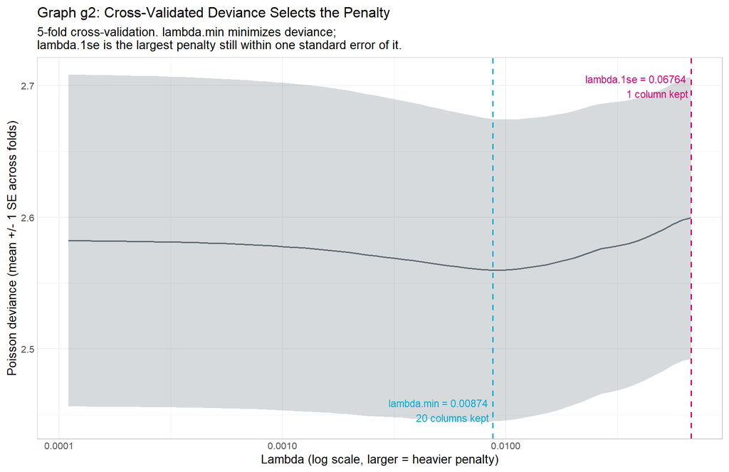

Graph g2: Five-fold cross-validated Poisson deviance across the penalty grid, with the one-standard-error band. lambda.min minimizes deviance; lambda.1se is the largest penalty within one standard error of that minimum.

## What Each Penalty Retains

Table t2 is the headline, and it is not the result anticipated when this rehearsal was scoped.

**Retention by variable under both penalties**

```r
selection_table <- extract_coefficients(cv_fit, "lambda.1se") %>%
  rename(estimate_1se = estimate) %>%
  left_join(
    extract_coefficients(cv_fit, "lambda.min") %>% rename(estimate_min = estimate),
    by = "column"
  ) %>%
  left_join(design$map, by = "column") %>%
  mutate(
    variable_label = variable_labels[variable],
    level = strip_variable_prefix(column, variable),
    kept_1se = estimate_1se != 0,
    kept_min = estimate_min != 0
  )

selection_summary <- selection_table %>%
  group_by(Variable = variable_label) %>%
  summarise(
    `Columns` = n(),
    `Kept at lambda.1se` = sum(kept_1se),
    `Kept at lambda.min` = sum(kept_min),
    .groups = "drop"
  ) %>%
  arrange(desc(`Kept at lambda.min`), Variable)

n_col_1se <- sum(selection_table$kept_1se)
n_col_min <- sum(selection_table$kept_min)
n_var_1se <- dplyr::n_distinct(selection_table$variable[selection_table$kept_1se])
n_var_min <- dplyr::n_distinct(selection_table$variable[selection_table$kept_min])

selection_summary %>%
  bind_rows(
    tibble::tibble(
      Variable = "TOTAL (columns)",
      Columns = nrow(selection_table),
      `Kept at lambda.1se` = n_col_1se,
      `Kept at lambda.min` = n_col_min
    )
  ) %>%
  print_table(
    caption = paste0(
      "Table t2: Retention by variable. At lambda.1se, ", n_col_1se, " of ",
      nrow(selection_table), " columns survive (", n_var_1se,
      " source variables). At lambda.min, ", n_col_min, " columns survive (",
      n_var_min, " source variables)."
    ),
    align = c("l", "r", "r", "r")
  )
```

Table t2: Retention by variable. At lambda.1se, 1 of 27 columns survive (1 source variables). At lambda.min, 20 columns survive (12 source variables).

| Variable | Columns | Kept at lambda.1se | Kept at lambda.min |
| --- | --- | --- | --- |
| Living arrangements | 7 | 0 | 4 |
| Age group | 2 | 0 | 2 |
| Education | 3 | 0 | 2 |
| Household size | 4 | 0 | 2 |
| Immigration status | 2 | 0 | 2 |
| Marital status | 3 | 0 | 2 |
| CCHS cycle | 1 | 1 | 1 |
| Child aged 0-5 in household | 1 | 0 | 1 |
| Child aged 6-11 in household | 1 | 0 | 1 |
| Home ownership | 1 | 0 | 1 |
| Sex | 1 | 0 | 1 |
| Visible minority | 1 | 0 | 1 |
| TOTAL (columns) | 27 | 1 | 20 |

**At `lambda.1se`, not one predisposing variable survives.** The single retained column is the cycle indicator, which was exempted from the penalty and therefore could not have been dropped. The one-standard-error rule concludes that, for predicting workdays lost to chronic conditions, the entire predisposing domain adds nothing that cross-validation can distinguish from noise.

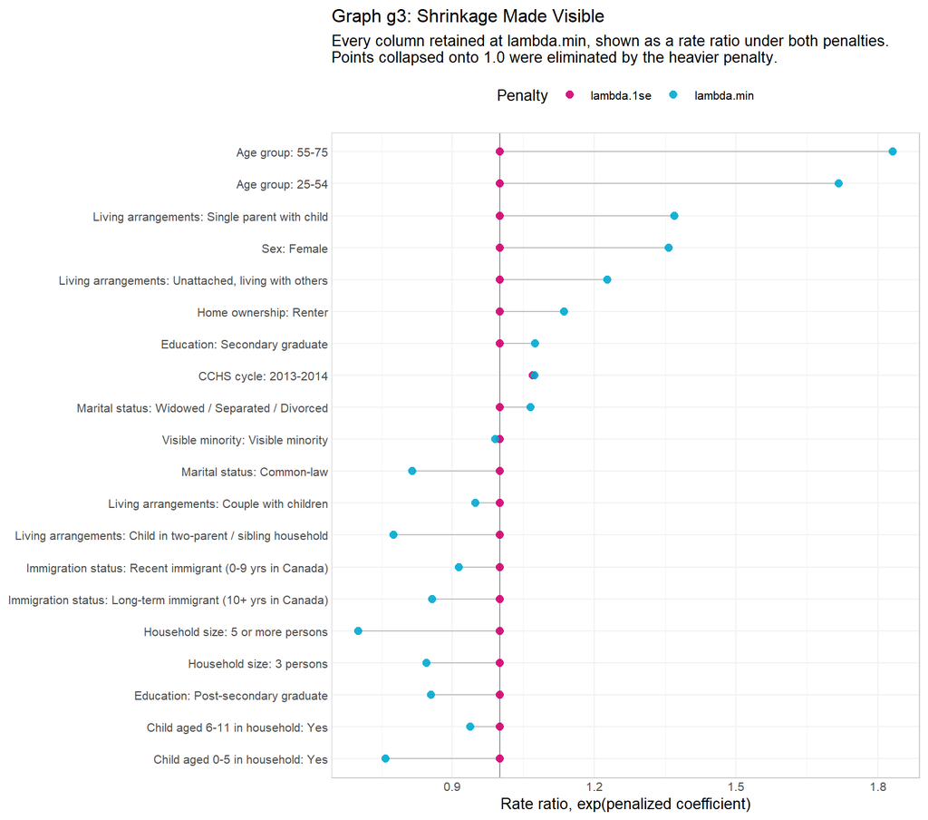

Graph g3: Every design column retained at lambda.min, expressed as a rate ratio under both penalties. Points resting exactly on 1.0 were eliminated by the heavier penalty.

## Stage Two: Handing Selection to Negative Binomial

Section 5.4 selects with a penalized Poisson model and re-estimates with an unpenalized negative binomial one. Table t3 demonstrates that handoff.

Because `lambda.1se` retained nothing, the demonstration necessarily uses the `lambda.min` set — the Model 3 analogue rather than the Model 1 analogue. The carry-forward rule applied here is that a variable enters stage two if *any* of its dummy columns survived. That rule is a choice, not a given, and it is one of the decisions listed at the end of this report.

**These estimates hold only inside this predictor universe**

Everything in this section is conditional on **what the penalty was shown**.

LASSO does not measure whether a variable is associated with the outcome. It measures whether a variable earns its place *against its competitors*. Every competitor offered here comes from the predisposing domain alone. Chronic conditions, perceived health, activity limitations, income, occupation and work schedule were all withheld — and on substantive grounds those withheld variables are nearer causes of work absence than marital status or household composition.

The consequence is that part of what the surviving terms measure is **borrowed**. Age, household size and living arrangement are correlated with the chronic conditions that were not offered, so they absorb signal that properly belongs to those conditions. This is not a defect in the estimation; it is what a regression does when a cause is omitted and a correlate of it is present.

Offer the omitted causes — as Model 1 does, with the full 47-variable candidate set — and these terms can be expected to weaken or disappear from the retained set entirely. Model 1 bears this out: of the eleven predisposing variables examined here, only one survives at `lambda.1se` once the chronic conditions and activity limitations compete for the same penalty budget.

Read this section as a statement about what predisposing characteristics do **in the absence of anything better**, not as an estimate of their effect.

**The two stages side by side on the lambda.min variable set**

```r
retained_variables_1se <- selection_table %>%
  filter(kept_1se) %>%
  pull(variable) %>%
  unique()

retained_variables_min <- selection_table %>%
  filter(kept_min) %>%
  pull(variable) %>%
  unique()

nb_variables <- union(forced_vars, setdiff(retained_variables_min, forced_vars))
nb_formula <- stats::reformulate(nb_variables, response = outcome_var)

nb_fit <- suppressWarnings(
  MASS::glm.nb(nb_formula, data = ds1, weights = weight_scaled)
)

nb_summary <- summary(nb_fit)$coefficients %>%
  as.data.frame() %>%
  tibble::rownames_to_column("column") %>%
  rename(estimate = Estimate, std_error = `Std. Error`, p_value = `Pr(>|z|)`) %>%
  filter(column != "(Intercept)") %>%
  left_join(design$map, by = "column") %>%
  left_join(selection_table %>% select(column, estimate_min, kept_min), by = "column") %>%
  mutate(
    variable_label = variable_labels[variable],
    level = strip_variable_prefix(column, variable),
    penalised_rr = exp(estimate_min),
    rate_ratio = exp(estimate),
    ci_low = exp(estimate - 1.96 * std_error),
    ci_high = exp(estimate + 1.96 * std_error),
    interval_excludes_one = ci_low > 1 | ci_high < 1
  )

# Levels that the penalty zeroed but that re-enter stage two anyway, because
# their parent variable had at least one surviving level (decision: carry the
# whole variable, not the surviving columns).
n_readmitted <- sum(!nb_summary$kept_min)

nb_summary %>%
  transmute(
    Variable = variable_label,
    Level = level,
    `Penalised RR` = ifelse(kept_min, sprintf("%.3f", penalised_rr),
                            sprintf("%.3f \u2020", penalised_rr)),
    `Refit RR` = sprintf("%.3f", rate_ratio),
    `95% CI` = sprintf("%.3f - %.3f", ci_low, ci_high),
    `p-value` = ifelse(p_value < 0.001, "<0.001", sprintf("%.3f", p_value))
  ) %>%
  print_table(
    caption = paste0(
      "Table t3: The two stages side by side, on the ", length(nb_variables),
      " variables retained at lambda.min. 'Penalised RR' is the shrunken LASSO ",
      "estimate; 'Refit RR' is the unpenalised negative binomial estimate. ",
      "A dagger marks the ", n_readmitted, " levels the penalty had zeroed that ",
      "re-enter because a sibling level survived. Wald intervals only, not ",
      "bootstrap, and they ignore the selection step entirely."
    ),
    align = c("l", "l", "r", "r", "r", "r")
  )
```

Table t3: The two stages side by side, on the 12 variables retained at lambda.min. ‘Penalised RR’ is the shrunken LASSO estimate; ‘Refit RR’ is the unpenalised negative binomial estimate. A dagger marks the 6 levels the penalty had zeroed that re-enter because a sibling level survived. Wald intervals only, not bootstrap, and they ignore the selection step entirely.

| Variable | Level | Penalised RR | Refit RR | 95% CI | p-value |
| --- | --- | --- | --- | --- | --- |
| CCHS cycle | 2013-2014 | 1.073 | 1.060 | 0.941 - 1.195 | 0.335 |
| Age group | 25-54 | 1.717 | 2.610 | 2.059 - 3.310 | <0.001 |
| Age group | 55-75 | 1.831 | 3.160 | 2.382 - 4.192 | <0.001 |
| Sex | Female | 1.357 | 1.540 | 1.365 - 1.738 | <0.001 |
| Marital status | Common-law | 0.816 | 0.843 | 0.696 - 1.023 | 0.083 |
| Marital status | Widowed / Separated / Divorced | 1.065 | 1.071 | 0.720 - 1.592 | 0.735 |
| Marital status | Single / Never married | 1.000 † | 0.982 | 0.682 - 1.416 | 0.924 |
| Household size | 2 persons | 1.000 † | 0.686 | 0.423 - 1.114 | 0.128 |
| Household size | 3 persons | 0.845 | 0.761 | 0.518 - 1.118 | 0.165 |
| Household size | 4 persons | 1.000 † | 1.033 | 0.702 - 1.520 | 0.870 |
| Household size | 5 or more persons | 0.701 | 0.658 | 0.447 - 0.971 | 0.035 |
| Child aged 0-5 in household | Yes | 0.758 | 0.664 | 0.546 - 0.808 | <0.001 |
| Child aged 6-11 in household | Yes | 0.938 | 0.874 | 0.721 - 1.059 | 0.169 |
| Education | Secondary graduate | 1.075 | 1.223 | 0.961 - 1.558 | 0.102 |
| Education | Some post-secondary | 1.000 † | 1.214 | 0.899 - 1.639 | 0.205 |
| Education | Post-secondary graduate | 0.855 | 0.928 | 0.747 - 1.152 | 0.496 |
| Immigration status | Long-term immigrant (10+ yrs in Canada) | 0.857 | 0.778 | 0.642 - 0.942 | 0.010 |
| Immigration status | Recent immigrant (0-9 yrs in Canada) | 0.914 | 0.624 | 0.470 - 0.829 | 0.001 |
| Visible minority | Visible minority | 0.991 | 0.904 | 0.753 - 1.086 | 0.283 |
| Home ownership | Renter | 1.136 | 1.265 | 1.083 - 1.476 | 0.003 |
| Living arrangements | Unattached, living with others | 1.228 | 1.674 | 1.074 - 2.610 | 0.023 |
| Living arrangements | Couple, no children | 1.000 † | 1.318 | 0.844 - 2.057 | 0.225 |
| Living arrangements | Couple with children | 0.949 | 0.924 | 0.692 - 1.232 | 0.590 |
| Living arrangements | Single parent with child | 1.370 | 1.923 | 1.191 - 3.105 | 0.007 |
| Living arrangements | Child in parent / sibling household | 1.000 † | 1.396 | 0.846 - 2.304 | 0.192 |
| Living arrangements | Child in two-parent / sibling household | 0.776 | 0.807 | 0.546 - 1.193 | 0.283 |

Table t3 places the penalized and unpenalized estimates in adjacent columns, which makes the division of labour between the stages legible. The penalized column answers “does this term belong?”; the refit column answers “how much does it matter?” They are different quantities, and the gap between them is the shrinkage the penalty imposed. Terms marked with a dagger are levels the penalty had driven to zero that re-enter anyway, because a sibling level of the same factor survived — the carry-forward rule made visible.

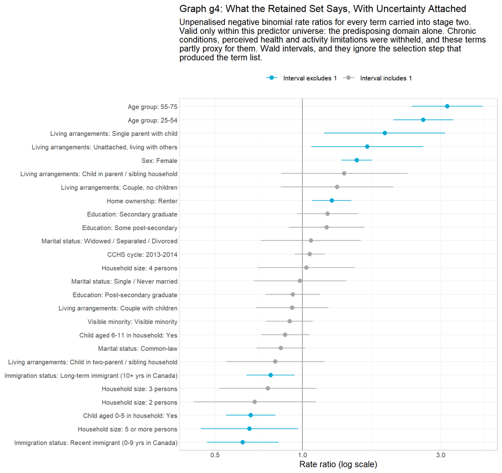

Graph g4: Unpenalized negative binomial rate ratios with 95% Wald intervals, for every term carried into stage two. Valid only within this predictor universe. Terms coloured grey have intervals overlapping 1.0.

Graph g4 is the interpretable face of the solution, and it repays a moment’s scepticism. The largest rate ratios attach to age and to living arrangements involving a single parent or an unattached adult — exactly the characteristics one would expect to correlate with the chronic conditions that were withheld. The colouring separates terms whose interval clears 1.0 from those whose does not, but that separation is not a significance test: the intervals ignore both the survey design and the selection step that produced the term list, and each of those omissions makes them narrower than they should be.

The intervals in Table t3 and Graph g4 are Wald intervals from a single model fit. They are **not** the bootstrap intervals that Sections 5.5 through 5.9 require, and they should not be read as inferential. Two separate reasons: the Statistics Canada replicate weights have not been applied — indeed they do not exist for these cycles — and the variables were selected using the same data used to estimate them, which invalidates naive standard errors regardless of how the variance is computed.

Output out3 shows why stage two is not optional. The Poisson fit is overdispersed by a factor of roughly two and a half on the deviance scale, and the negative binomial dispersion parameter is small enough to imply enormous excess variance. The improvement in AIC is not marginal.

**Overdispersion diagnostics and Poisson vs negative binomial fit**

```r
# Why the second stage is needed at all: the Poisson variance assumption fails
# badly, and the negative binomial dispersion parameter measures by how much.
poisson_fit <- stats::glm(
  nb_formula, data = ds1, family = stats::poisson(), weights = weight_scaled
)

cat("Predisposing variables retained at lambda.1se: ",
    length(setdiff(retained_variables_1se, forced_vars)), "\n")
```

```
Predisposing variables retained at lambda.1se:  0
```

**Overdispersion diagnostics and Poisson vs negative binomial fit**

```r
cat("Predisposing variables retained at lambda.min: ",
    length(setdiff(retained_variables_min, forced_vars)), "\n")
```

```
Predisposing variables retained at lambda.min:  11
```

**Overdispersion diagnostics and Poisson vs negative binomial fit**

```r
cat("Variables carried into stage 2: ", length(nb_variables), "\n")
```

```
Variables carried into stage 2:  12
```

**Overdispersion diagnostics and Poisson vs negative binomial fit**

```r
cat("  ", paste(nb_variables, collapse = ", "), "\n\n")
```

```
   cchs_cycle_f, age_group_3, sex, marital_status, household_size, dhhgle5, dhhg611, education, immigration_status, visible_minority, home_ownership, living_arrangements
```

**Overdispersion diagnostics and Poisson vs negative binomial fit**

```r
cat("Poisson residual deviance / df: ",
    sprintf("%.2f", poisson_fit$deviance / poisson_fit$df.residual),
    "  (1.0 indicates no overdispersion)\n")
```

```
Poisson residual deviance / df:  2.51   (1.0 indicates no overdispersion)
```

**Overdispersion diagnostics and Poisson vs negative binomial fit**

```r
cat("Negative binomial theta:        ", sprintf("%.4f", nb_fit$theta),
    " (SE ", sprintf("%.4f", nb_fit$SE.theta), ")\n")
```

```
Negative binomial theta:         0.0188  (SE  0.0004 )
```

**Overdispersion diagnostics and Poisson vs negative binomial fit**

```r
cat("Implied variance at the mean:   ",
    sprintf("%.3f", mean(stats::fitted(nb_fit)) *
              (1 + mean(stats::fitted(nb_fit)) / nb_fit$theta)),
    " vs Poisson ", sprintf("%.3f", mean(stats::fitted(nb_fit))), "\n\n")
```

```
Implied variance at the mean:    9.465  vs Poisson  0.413
```

**Overdispersion diagnostics and Poisson vs negative binomial fit**

```r
cat("AIC, Poisson:           ", sprintf("%.0f", stats::AIC(poisson_fit)), "\n")
```

```
AIC, Poisson:            166216
```

**Overdispersion diagnostics and Poisson vs negative binomial fit**

```r
cat("AIC, negative binomial: ", sprintf("%.0f", stats::AIC(nb_fit)), "\n")
```

```
AIC, negative binomial:  43489
```

## Do the Survey Weights Disturb Cross-Validation?

A result as stark as “nothing survives `lambda.1se`” deserves interrogation before it is believed. One candidate explanation is mechanical rather than substantive.

The pooled master weights span three orders of magnitude. Highly variable weights inflate the variance of any weighted estimate, including the fold-to-fold variance of cross-validated deviance. A wider standard-error band pushes `lambda.1se` further from `lambda.min`, and therefore prunes harder. Output out4 isolates this by re-running the identical cross-validation without weights.

**Weight variability and its effect on penalty selection**

```r
# Is the lambda.1se collapse a property of the data or an artifact of the survey
# weights? Survey weights range across three orders of magnitude, which inflates
# the cross-validation standard error and therefore pushes lambda.1se upward.
# Re-running the identical cross-validation unweighted isolates that effect.
set.seed(lasso_seed)
cv_unweighted <- glmnet::cv.glmnet(
  x = x_matrix,
  y = y_outcome,
  family = "poisson",
  alpha = 1,
  nfolds = lasso_folds,
  penalty.factor = penalty_vector
)

count_nonzero <- function(fit, lambda_label) {
  sum(as.numeric(stats::coef(fit, s = lambda_label))[-1] != 0)
}

cat("Survey weight range: ", sprintf("%.2f to %.2f", min(ds1[[weight_col]]),
                                     max(ds1[[weight_col]])), "\n")
```

```
Survey weight range:  3.02 to 13166.31
```

**Weight variability and its effect on penalty selection**

```r
cat("Weight coefficient of variation: ",
    sprintf("%.2f", stats::sd(weight_vector) / mean(weight_vector)), "\n")
```

```
Weight coefficient of variation:  1.61
```

**Weight variability and its effect on penalty selection**

```r
cat("Kish effective sample size: ",
    sprintf("%.0f of %d",
            sum(weight_vector)^2 / sum(weight_vector^2), nrow(ds1)), "\n\n")
```

```
Kish effective sample size:  17264 of 62017
```

**Weight variability and its effect on penalty selection**

```r
cat("Columns retained, weighted CV:   lambda.1se = ",
    count_nonzero(cv_fit, "lambda.1se"), ", lambda.min = ",
    count_nonzero(cv_fit, "lambda.min"), "\n")
```

```
Columns retained, weighted CV:   lambda.1se =  1 , lambda.min =  20
```

**Weight variability and its effect on penalty selection**

```r
cat("Columns retained, unweighted CV: lambda.1se = ",
    count_nonzero(cv_unweighted, "lambda.1se"), ", lambda.min = ",
    count_nonzero(cv_unweighted, "lambda.min"), "\n")
```

```
Columns retained, unweighted CV: lambda.1se =  9 , lambda.min =  21
```

**Weight variability and its effect on penalty selection**

```r
# nolint end
```

# What Model 0 Settles, and What It Does Not

## Confirmed

The Section 5.4 machinery works as written. `glmnet` fits a weighted penalized Poisson model on CCHS data at this scale without difficulty; both penalties are recoverable from a single cross-validated fit; and the selected set transfers to `MASS::glm.nb` cleanly. Nothing in the proposal’s Stage 1 to Stage 2 design is obstructed by our data.

## Open decisions for Section 5.4

**2. Reference coding or one-hot?** Model 0 uses treatment contrasts, so each factor contributes $k-1$ columns and the reference level is unpenalized by construction. The proposal’s snippet (`model.matrix(~ . - 1, ...)`) yields full one-hot coding for the first factor and reference coding for the rest, which is internally inconsistent. Under one-hot coding the reference level competes for retention like any other, and selection results change.

**3. What is the carry-forward rule?** When two of a factor’s four columns survive, does the whole factor enter stage two, or only the retained levels? Model 0 assumed the whole factor. The alternative produces non-standard contrasts whose interpretation is awkward but whose parsimony is greater.

**4. Should selection be design-aware?** `cv.glmnet` accepts observation weights but draws cross-validation folds as though observations were independent, and it cannot accept replicate weights at all. The penalty is therefore chosen under a design-naive criterion even when the likelihood is weighted. Output out4 shows this is not a negligible detail.

**5. Is `lambda.1se` viable as the primary specification?** Section 5.5 designates the `lambda.1se` model as primary. On the predisposing domain against `days_absent_chronic`, that specification is empty. Whether it remains empty once the chronic-condition exposures, facilitating variables, and needs variables are added is the single most important thing to test next.

## A note on scope

Model 0 used one domain and one outcome by design. Three restrictions bound how far its results generalize.

The outcome is the *sensitivity* outcome, not the primary one. At 94.31% zeros, `days_absent_chronic` is far harsher than `days_absent_total` at roughly 70%. Weak selection here does not imply weak selection there.

The predisposing domain is, on theoretical grounds, the domain expected to carry the least direct signal. Andersen’s framework positions predisposing characteristics as distal, acting largely through the enabling and need factors that Model 0 excludes. A domain that selects poorly in isolation may still contribute once the mediating variables are present.

Most importantly, **selection is a relative verdict, and the comparison set here is narrow by construction.** A variable is retained because it beat the alternatives it was shown, not because it is important in any absolute sense. Restricting the universe to the predisposing domain does two things at once: it removes the variables most likely to win, and it leaves the survivors carrying signal that belongs to those absent variables. Both effects inflate what the retained terms appear to say. Model 1, which offers all forty-seven candidates simultaneously, retains exactly one predisposing variable at `lambda.1se` — a direct measurement of how much of Model 0’s apparent structure was borrowed rather than earned.

And no attempt was made at group LASSO, at bootstrap variance estimation, or at the performance metrics of Section 5.6. Those belong to the real implementation.

# Session Information

```
Report rendered in  16  seconds.
```